# Final Project

Now that you've been guided which experiment to run in assignment 2, you will be exploring on your own, trying to achieve the best accuracy for cifar10.

In this notebook you will be asked to tune some hyperparameters, while it is recommended to tune additional hyperparameters to achieve high performance.

In addition, you will be asked to read some matirials by yourselves, summeraize some of them, and combine thier innovaitive ideas in your network.

You can use part of the data, in order to speed up the training, however, the **dataset size** you test on should be large. Use at least ~12000 training images and ~3000 validation images. The **batch size** parameter however is also up to you (you can increase it in order to speed up the training).

You can run the experiments from several notebooks, while you save the output files in the results dictionary (choose meaningful names) and use 'plot_exp_results' to plot it.

You may want to use loops in order to automatically run each section's experiments.

You will will submit this notebook, all relevant the python files and a report that summerize your attempts and results. Follow the instructions and answer the question in your report.

It is important to describe the hyperparameters you used, how you chose them, and how they affected your results.

**In each section write the best train val and test accuracy and loss.**

```python
!pip install tqdm==4.17.1
import os
import re
import sys
import glob
import numpy as np
import matplotlib.pyplot as plt
import unittest
import torch
import torchvision
import torchvision.transforms as tvtf
import torch.nn as nn
import torch.optim as optim


%matplotlib inline
%load_ext autoreload
%autoreload 2

seed = 42
device = torch.device('cuda' if torch.cuda.is_available() else 'cpu')

plt.rcParams.update({'font.size': 12})
test = unittest.TestCase()
```

[output not shown]

```python
from google.colab import drive
drive.mount('/content/drive')
#change this
%cd /content/drive/My\ Drive/deepLearning/final
```

```
/content/drive/My Drive/deepLearning/final
```

```python
from utils import *
from  utils import models
import utils.experiments as experiments
from utils.experiments import load_experiment
from utils.plot import plot_fit
import utils.training as training
torch.manual_seed(seed)
```

```
<torch._C.Generator at 0x7fbe9c6868d0>
```

```python
def plot_exp_results(filename_pattern, results_dir='results'):
    fig = None
    result_files = glob.glob(os.path.join(results_dir, filename_pattern))
    result_files.sort()
    if len(result_files) == 0:
        print(f'No results found for pattern {filename_pattern}.', file=sys.stderr)
        return
    for filepath in result_files:
        m = re.match('exp\d_(\d_)?(.*)\.json', os.path.basename(filepath))
        cfg, fit_res = load_experiment(filepath)
        fig, axes = plot_fit(fit_res, fig, legend=m[2],log_loss=True)
    del cfg['filters_per_layer']
    del cfg['layers_per_block']
    print('common config: ', cfg)
```

## Build Your Own Achitecture

```python
data_dir = os.path.expanduser('~/.pytorch-datasets')
ds_train = torchvision.datasets.CIFAR10(root=data_dir, download=True, train=True, transform=tvtf.ToTensor())
ds_test = torchvision.datasets.CIFAR10(root=data_dir, download=True, train=False, transform=tvtf.ToTensor())

print(f'Train: {len(ds_train)} samples')
print(f'Test: {len(ds_test)} samples')

x0,_ = ds_train[0]
in_size = x0.shape
num_classes = 10
print('input image size =', in_size)
```

```
Downloading https://www.cs.toronto.edu/~kriz/cifar-10-python.tar.gz to /root/.pytorch-datasets/cifar-10-python.tar.gz
```

```
Extracting /root/.pytorch-datasets/cifar-10-python.tar.gz to /root/.pytorch-datasets
Files already downloaded and verified
Train: 50000 samples
Test: 10000 samples
input image size = torch.Size([3, 32, 32])
```

### 1. Implement YourCodeNet model

Implement YourCodeNet model in utiles/models and define the model architecture (use your previouse assignment's insights). Define `filters_per_layer`, `layers_per_block` and `hidden_dims` which you believe are the best for this task. You can run some experiments in order to set these hyperparameters.

To make the experiment runner use your custom network model, remember to set ycn=True when you call experiments.run_experiment(...).

```python
# Just to see that the model run
net = models.YourCodeNet((3,100,100), 10, filters=[32]*4, pool_every=2, hidden_dims=[100]*2).to(device)
print(net)

test_image = torch.randint(low=0, high=256, size=(3, 100, 100), dtype=torch.float).to(device)
test_out = net(test_image.unsqueeze(0))
print('out =', test_out)
```

```
YourCodeNet(
  (feature_extractor): Sequential(
    (0): Conv2d(3, 32, kernel_size=(3, 3), stride=(1, 1), padding=(1, 1))
    (1): ReLU(inplace=True)
    (2): Conv2d(32, 32, kernel_size=(3, 3), stride=(1, 1), padding=(1, 1))
    (3): ReLU(inplace=True)
    (4): MaxPool2d(kernel_size=2, stride=2, padding=0, dilation=1, ceil_mode=False)
    (5): Conv2d(32, 32, kernel_size=(3, 3), stride=(1, 1), padding=(1, 1))
    (6): ReLU(inplace=True)
    (7): Conv2d(32, 32, kernel_size=(3, 3), stride=(1, 1), padding=(1, 1))
    (8): ReLU(inplace=True)
    (9): MaxPool2d(kernel_size=2, stride=2, padding=0, dilation=1, ceil_mode=False)
  )
  (classifier): Sequential(
    (0): Linear(in_features=20000, out_features=100, bias=True)
    (1): ReLU(inplace=True)
    (2): Linear(in_features=100, out_features=100, bias=True)
    (3): ReLU(inplace=True)
    (4): Linear(in_features=100, out_features=10, bias=True)
  )
)
YourCodeNet(
  (feature_extractor): Sequential(
    (0): Conv2d(3, 32, kernel_size=(3, 3), stride=(1, 1), padding=(1, 1))
    (1): ReLU(inplace=True)
    (2): Conv2d(32, 32, kernel_size=(3, 3), stride=(1, 1), padding=(1, 1))
    (3): ReLU(inplace=True)
    (4): MaxPool2d(kernel_size=2, stride=2, padding=0, dilation=1, ceil_mode=False)
    (5): Conv2d(32, 32, kernel_size=(3, 3), stride=(1, 1), padding=(1, 1))
    (6): ReLU(inplace=True)
    (7): Conv2d(32, 32, kernel_size=(3, 3), stride=(1, 1), padding=(1, 1))
    (8): ReLU(inplace=True)
    (9): MaxPool2d(kernel_size=2, stride=2, padding=0, dilation=1, ceil_mode=False)
  )
  (classifier): Sequential(
    (0): Linear(in_features=20000, out_features=100, bias=True)
    (1): ReLU(inplace=True)
    (2): Linear(in_features=100, out_features=100, bias=True)
    (3): ReLU(inplace=True)
    (4): Linear(in_features=100, out_features=10, bias=True)
  )
)
out = tensor([[-0.0868, -0.3790, -0.4341, -0.1236, -0.2160,  0.1683,  0.4739,  0.0750,
          0.1151, -0.1606]], device='cuda:0', grad_fn=<AddmmBackward0>)
```

```python
# set ycn=True when you call experiments.run_experiment(...).
# Use meaningful names!
# ====== YOUR CODE: ======
for l in [2,4]:
    for k in [64,128]:
      for dims in [[100,100],[256,256]]:
        experiments.run_experiment(f'exp1_1_L{l}_K{k}_dim{dims[0]}',
                                   seed=seed,
                                   bs_train=50,
                                   batches=10000,
                                   epochs=20,
                                   early_stopping=5,
                                   reg=0,
                                   lr=1e-3,
                                   filters_per_layer=[k],
                                   layers_per_block=l,
                                   pool_every=4,
                                   hidden_dims=dims,
                                   ycn=True)
# ========================
```

```
Files already downloaded and verified
Files already downloaded and verified
YourCodeNet(
  (feature_extractor): Sequential(
    (0): Conv2d(3, 64, kernel_size=(3, 3), stride=(1, 1), padding=(1, 1))
    (1): ReLU(inplace=True)
    (2): Conv2d(64, 64, kernel_size=(3, 3), stride=(1, 1), padding=(1, 1))
    (3): ReLU(inplace=True)
  )
  (classifier): Sequential(
    (0): Linear(in_features=65536, out_features=100, bias=True)
    (1): ReLU(inplace=True)
    (2): Linear(in_features=100, out_features=100, bias=True)
    (3): ReLU(inplace=True)
    (4): Linear(in_features=100, out_features=10, bias=True)
  )
)
--- EPOCH 1/20 ---
train_batch (Avg. Loss 1.479, Accuracy 46.3): 100%|██████████| 850/850 [00:07<00:00, 111.81it/s]
test_batch (Avg. Loss 1.246, Accuracy 55.0): 100%|██████████| 625/625 [00:01<00:00, 390.62it/s]
--- EPOCH 2/20 ---
train_batch (Avg. Loss 1.116, Accuracy 60.2): 100%|██████████| 850/850 [00:07<00:00, 111.01it/s]
test_batch (Avg. Loss 1.099, Accuracy 60.5): 100%|██████████| 625/625 [00:01<00:00, 378.54it/s]
--- EPOCH 3/20 ---
train_batch (Avg. Loss 0.915, Accuracy 67.4): 100%|██████████| 850/850 [00:08<00:00, 104.53it/s]
test_batch (Avg. Loss 1.042, Accuracy 63.2): 100%|██████████| 625/625 [00:01<00:00, 410.37it/s]
--- EPOCH 4/20 ---
train_batch (Avg. Loss 0.748, Accuracy 73.5): 100%|██████████| 850/850 [00:07<00:00, 111.02it/s]
test_batch (Avg. Loss 1.056, Accuracy 63.6): 100%|██████████| 625/625 [00:01<00:00, 365.53it/s]
--- EPOCH 5/20 ---
train_batch (Avg. Loss 0.587, Accuracy 79.4): 100%|██████████| 850/850 [00:07<00:00, 110.99it/s]
test_batch (Avg. Loss 1.092, Accuracy 64.9): 100%|██████████| 625/625 [00:01<00:00, 390.10it/s]
--- EPOCH 6/20 ---
train_batch (Avg. Loss 0.447, Accuracy 84.1): 100%|██████████| 850/850 [00:07<00:00, 106.44it/s]
test_batch (Avg. Loss 1.194, Accuracy 64.1): 100%|██████████| 625/625 [00:01<00:00, 402.01it/s]
--- EPOCH 7/20 ---
train_batch (Avg. Loss 0.320, Accuracy 88.9): 100%|██████████| 850/850 [00:07<00:00, 111.81it/s]
test_batch (Avg. Loss 1.406, Accuracy 64.6): 100%|██████████| 625/625 [00:01<00:00, 395.37it/s]
--- EPOCH 8/20 ---
train_batch (Avg. Loss 0.227, Accuracy 92.1): 100%|██████████| 850/850 [00:07<00:00, 106.79it/s]
```

[output cut: 392 more lines]

```
--- EPOCH 7/20 ---
train_batch (Avg. Loss 0.171, Accuracy 94.2): 100%|██████████| 850/850 [00:24<00:00, 35.29it/s]
test_batch (Avg. Loss 1.695, Accuracy 66.4): 100%|██████████| 625/625 [00:02<00:00, 254.12it/s]
--- EPOCH 8/20 ---
train_batch (Avg. Loss 0.129, Accuracy 95.5): 100%|██████████| 850/850 [00:24<00:00, 35.39it/s]
test_batch (Avg. Loss 1.760, Accuracy 66.2): 100%|██████████| 625/625 [00:02<00:00, 249.13it/s]
--- EPOCH 9/20 ---
train_batch (Avg. Loss 0.103, Accuracy 96.5): 100%|██████████| 850/850 [00:24<00:00, 35.18it/s]
test_batch (Avg. Loss 2.014, Accuracy 65.7): 100%|██████████| 625/625 [00:02<00:00, 249.38it/s]
test_batch (Avg. Loss 1.995, Accuracy 65.9): 100%|██████████| 834/834 [00:06<00:00, 130.76it/s]
==================== Test Results ====================
Test Accuracy: 65.91
Test Accuracy: 1.995046362125695
======================================================
*** Output file ./results/exp1_1_L4_K128_dim256.json written
```

```
common config:  {'run_name': 'exp1_1_L2_K64_dim256', 'out_dir': './results', 'seed': 42, 'bs_train': 50, 'bs_test': 12, 'batches': 10000, 'epochs': 20, 'early_stopping': 5, 'checkpoints': None, 'lr': 0.001, 'reg': 0, 'pool_every': 4, 'hidden_dims': [256, 256], 'ycn': True, 'kw': {}}
common config:  {'run_name': 'exp1_1_L4_K64_dim256', 'out_dir': './results', 'seed': 42, 'bs_train': 50, 'bs_test': 12, 'batches': 10000, 'epochs': 20, 'early_stopping': 5, 'checkpoints': None, 'lr': 0.001, 'reg': 0, 'pool_every': 4, 'hidden_dims': [256, 256], 'ycn': True, 'kw': {}}
```

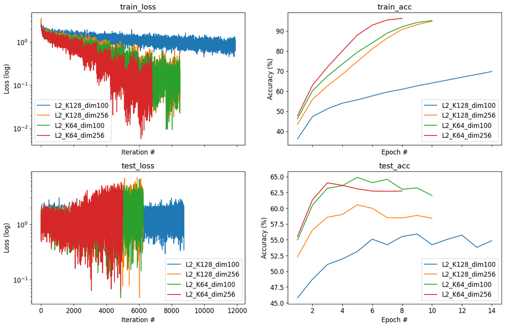

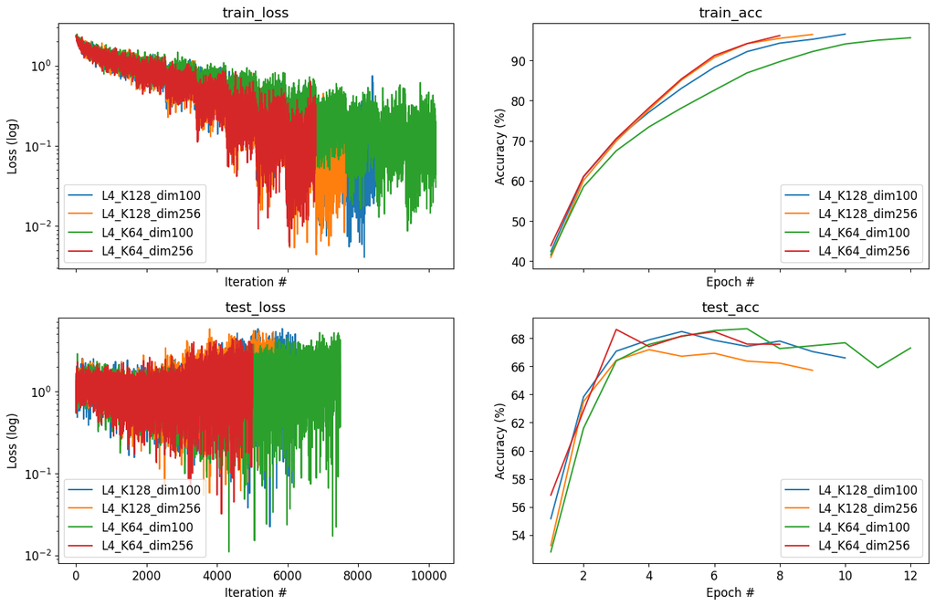

```python
for l in [2,4]:
      plot_exp_results(f'exp1_1_L{l}*.json') # plot your experiments results
```

### 2. Learning rate and optimization method

Tune the optimization algorithm (try SGD with momentum and Adam) and the learning rate (try values between 0.0005-1, try no more than five values).

```python
# set ycn=True when you call experiments.run_experiment(...).
# Use meaningful names!
# ====== YOUR CODE: ======
for lr in [0.0005, 0.001, 0.01, 0.1, 1.0]:
    experiments.run_experiment(f'exp2_lr{lr}_SGD',
                                seed=seed,
                                bs_train=50,
                                batches=10000,
                                epochs=20,
                                early_stopping=3,
                                reg=0,
                                lr=lr,
                                filters_per_layer=[64],
                                layers_per_block=4,
                                pool_every=4,
                                hidden_dims=[100,100],
                                ycn=True,
                                optimizer="SGD")

for lr in [0.0005, 0.001, 0.01, 0.1, 1.0]:
    experiments.run_experiment(f'exp2_lr{lr}_Adam',
                                seed=seed,
                                bs_train=50,
                                batches=10000,
                                epochs=20,
                                early_stopping=3,
                                reg=0,
                                lr=lr,
                                filters_per_layer=[64],
                                layers_per_block=4,
                                pool_every=4,
                                hidden_dims=[100,100],
                                ycn=True,
                                optimizer="Adam")
# ========================
```

```
Files already downloaded and verified
Files already downloaded and verified
YourCodeNet(
  (feature_extractor): Sequential(
    (0): Conv2d(3, 64, kernel_size=(3, 3), stride=(1, 1), padding=(1, 1))
    (1): ReLU(inplace=True)
    (2): Conv2d(64, 64, kernel_size=(3, 3), stride=(1, 1), padding=(1, 1))
    (3): ReLU(inplace=True)
    (4): Conv2d(64, 64, kernel_size=(3, 3), stride=(1, 1), padding=(1, 1))
    (5): ReLU(inplace=True)
    (6): Conv2d(64, 64, kernel_size=(3, 3), stride=(1, 1), padding=(1, 1))
    (7): ReLU(inplace=True)
    (8): MaxPool2d(kernel_size=2, stride=2, padding=0, dilation=1, ceil_mode=False)
  )
  (classifier): Sequential(
    (0): Linear(in_features=16384, out_features=100, bias=True)
    (1): ReLU(inplace=True)
    (2): Linear(in_features=100, out_features=100, bias=True)
    (3): ReLU(inplace=True)
    (4): Linear(in_features=100, out_features=10, bias=True)
  )
)
--- EPOCH 1/20 ---
train_batch (Avg. Loss 2.304, Accuracy 10.0): 100%|██████████| 850/850 [00:11<00:00, 77.16it/s]
test_batch (Avg. Loss 2.304, Accuracy 10.1): 100%|██████████| 625/625 [00:01<00:00, 330.16it/s]
--- EPOCH 2/20 ---
train_batch (Avg. Loss 2.304, Accuracy 10.0): 100%|██████████| 850/850 [00:10<00:00, 78.21it/s]
test_batch (Avg. Loss 2.304, Accuracy 10.1): 100%|██████████| 625/625 [00:01<00:00, 323.88it/s]
--- EPOCH 3/20 ---
train_batch (Avg. Loss 2.303, Accuracy 10.0): 100%|██████████| 850/850 [00:10<00:00, 78.46it/s]
test_batch (Avg. Loss 2.304, Accuracy 10.1): 100%|██████████| 625/625 [00:01<00:00, 327.23it/s]
--- EPOCH 4/20 ---
train_batch (Avg. Loss 2.303, Accuracy 10.0): 100%|██████████| 850/850 [00:10<00:00, 78.25it/s]
test_batch (Avg. Loss 2.304, Accuracy 10.1): 100%|██████████| 625/625 [00:01<00:00, 349.53it/s]
test_batch (Avg. Loss 2.303, Accuracy 10.0): 100%|██████████| 834/834 [00:04<00:00, 169.50it/s]
==================== Test Results ====================
Test Accuracy: 10.0
Test Accuracy: 2.303164820591037
======================================================
*** Output file ./results/exp2_lr0.0005_SGD.json written
```

[output cut: 483 more lines]

```
--- EPOCH 10/20 ---
train_batch (Avg. Loss 2.385, Accuracy 9.9): 100%|██████████| 850/850 [00:11<00:00, 76.29it/s]
test_batch (Avg. Loss 2.350, Accuracy 10.1): 100%|██████████| 625/625 [00:01<00:00, 341.09it/s]
--- EPOCH 11/20 ---
train_batch (Avg. Loss 2.389, Accuracy 10.0): 100%|██████████| 850/850 [00:11<00:00, 74.15it/s]
test_batch (Avg. Loss 2.379, Accuracy 9.6): 100%|██████████| 625/625 [00:01<00:00, 345.16it/s]
--- EPOCH 12/20 ---
train_batch (Avg. Loss 2.377, Accuracy 10.2): 100%|██████████| 850/850 [00:11<00:00, 75.52it/s]
test_batch (Avg. Loss 2.322, Accuracy 10.5): 100%|██████████| 625/625 [00:02<00:00, 310.75it/s]
test_batch (Avg. Loss 2.323, Accuracy 10.0): 100%|██████████| 834/834 [00:05<00:00, 148.02it/s]
==================== Test Results ====================
Test Accuracy: 10.0
Test Accuracy: 2.3229837632007735
======================================================
*** Output file ./results/exp2_lr1.0_Adam.json written
```

```
common config:  {'run_name': 'exp2_lr1.0_SGD', 'out_dir': './results', 'seed': 42, 'bs_train': 50, 'bs_test': 12, 'batches': 10000, 'epochs': 20, 'early_stopping': 3, 'checkpoints': None, 'lr': 1.0, 'reg': 0, 'pool_every': 4, 'hidden_dims': [100, 100], 'ycn': True, 'kw': {'optimizer': 'SGD'}}
```

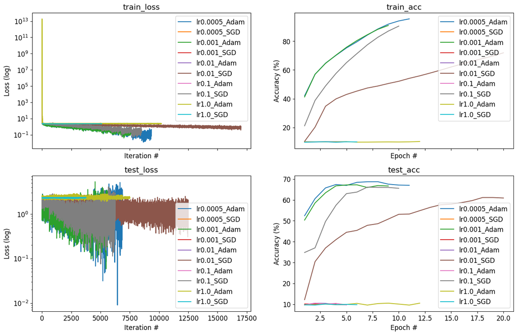

```python
for opt in ["Adam,SGD"]:
  plot_exp_results(f'exp2_lr*.json') # plot your experiments results
```

**Answer in your Report:** Why should we add the momentum to SGD? What is the main two improvments adam has comparing to the simple SGD? What was the best optimization algorithm and best learning rate you've found?

Summarize this section results in your report.

**Note** - you will need to change the optimization used in experiments.run_experiment(...).

### Answer:

We should add momentum to SGD because the momentum allows the optimizer to accumulate velocity in the direction of the previous gradients, making it move faster through flat or noisy regions therefore having more stability between epochs. **Adam's improvements:**

- Adjusts the learning rates for each parameter based of the mean and the variance of the gradients which makes it handle difference in gradients better, as if the data wasn't noisy.
- Corrects the bias, in the first learning iterations adam applies bias correction to counteract the initialization bias. Which handles better the first phases of the training process even if the bias is random and not initialized manually.

Adam with learning rate of 0.0005 worked best for me, reaching the best validation accuracy (it did overfit a bit but I believe it can be solved later).

### 3. Add Batch Normalization

Add batch normalization to your network. You may want to read this blog before: https://www.baeldung.com/cs/batch-normalization-cnn

```python
# set ycn=True when you call experiments.run_experiment(...)
# Use meaningful names!
# ====== YOUR CODE: ======
experiments.run_experiment(f'exp3_batch_normalization',
                                seed=seed,
                                bs_train=50,
                                batches=10000,
                                epochs=20,
                                early_stopping=5,
                                reg=0,
                                lr=0.0005,
                                filters_per_layer=[64],
                                layers_per_block=4,
                                pool_every=4,
                                hidden_dims=[100,100],
                                ycn=True,
                                optimizer="Adam")
# ========================
```

```
Files already downloaded and verified
Files already downloaded and verified
YourCodeNet(
  (feature_extractor): Sequential(
    (0): Conv2d(3, 64, kernel_size=(3, 3), stride=(1, 1), padding=(1, 1))
    (1): BatchNorm2d(64, eps=1e-05, momentum=0.1, affine=True, track_running_stats=True)
    (2): ReLU(inplace=True)
    (3): Conv2d(64, 64, kernel_size=(3, 3), stride=(1, 1), padding=(1, 1))
    (4): BatchNorm2d(64, eps=1e-05, momentum=0.1, affine=True, track_running_stats=True)
    (5): ReLU(inplace=True)
    (6): Conv2d(64, 64, kernel_size=(3, 3), stride=(1, 1), padding=(1, 1))
    (7): BatchNorm2d(64, eps=1e-05, momentum=0.1, affine=True, track_running_stats=True)
    (8): ReLU(inplace=True)
    (9): Conv2d(64, 64, kernel_size=(3, 3), stride=(1, 1), padding=(1, 1))
    (10): BatchNorm2d(64, eps=1e-05, momentum=0.1, affine=True, track_running_stats=True)
    (11): ReLU(inplace=True)
    (12): MaxPool2d(kernel_size=2, stride=2, padding=0, dilation=1, ceil_mode=False)
  )
  (classifier): Sequential(
    (0): Linear(in_features=16384, out_features=100, bias=True)
    (1): ReLU(inplace=True)
    (2): Linear(in_features=100, out_features=100, bias=True)
    (3): ReLU(inplace=True)
    (4): Linear(in_features=100, out_features=10, bias=True)
  )
)
--- EPOCH 1/20 ---
train_batch (Avg. Loss 1.301, Accuracy 53.1): 100%|██████████| 850/850 [00:14<00:00, 61.79it/s]
test_batch (Avg. Loss 1.111, Accuracy 61.1): 100%|██████████| 625/625 [00:01<00:00, 324.01it/s]
--- EPOCH 2/20 ---
train_batch (Avg. Loss 0.894, Accuracy 68.4): 100%|██████████| 850/850 [00:13<00:00, 65.29it/s]
test_batch (Avg. Loss 0.938, Accuracy 67.3): 100%|██████████| 625/625 [00:01<00:00, 329.43it/s]
--- EPOCH 3/20 ---
train_batch (Avg. Loss 0.740, Accuracy 73.9): 100%|██████████| 850/850 [00:12<00:00, 66.00it/s]
test_batch (Avg. Loss 0.824, Accuracy 71.6): 100%|██████████| 625/625 [00:01<00:00, 322.82it/s]
--- EPOCH 4/20 ---
train_batch (Avg. Loss 0.633, Accuracy 77.7): 100%|██████████| 850/850 [00:12<00:00, 65.86it/s]
test_batch (Avg. Loss 0.740, Accuracy 74.4): 100%|██████████| 625/625 [00:01<00:00, 325.04it/s]
--- EPOCH 5/20 ---
train_batch (Avg. Loss 0.546, Accuracy 80.8): 100%|██████████| 850/850 [00:12<00:00, 65.92it/s]
```

[output cut: 16 more lines]

```
--- EPOCH 11/20 ---
train_batch (Avg. Loss 0.182, Accuracy 93.6): 100%|██████████| 850/850 [00:12<00:00, 65.90it/s]
test_batch (Avg. Loss 1.038, Accuracy 74.0): 100%|██████████| 625/625 [00:01<00:00, 332.74it/s]
--- EPOCH 12/20 ---
train_batch (Avg. Loss 0.149, Accuracy 94.7): 100%|██████████| 850/850 [00:12<00:00, 65.81it/s]
test_batch (Avg. Loss 1.162, Accuracy 73.4): 100%|██████████| 625/625 [00:01<00:00, 332.52it/s]
--- EPOCH 13/20 ---
train_batch (Avg. Loss 0.135, Accuracy 95.2): 100%|██████████| 850/850 [00:12<00:00, 65.83it/s]
test_batch (Avg. Loss 1.255, Accuracy 72.9): 100%|██████████| 625/625 [00:01<00:00, 323.47it/s]
test_batch (Avg. Loss 1.296, Accuracy 72.4): 100%|██████████| 834/834 [00:04<00:00, 178.38it/s]
==================== Test Results ====================
Test Accuracy: 72.39
Test Accuracy: 1.2961304502514788
======================================================
*** Output file ./results/exp3_batch_normalization.json written
```

```
common config:  {'run_name': 'exp3_batch_normalization', 'out_dir': './results', 'seed': 42, 'bs_train': 50, 'bs_test': 12, 'batches': 10000, 'epochs': 20, 'early_stopping': 5, 'checkpoints': None, 'lr': 0.0005, 'reg': 0, 'pool_every': 4, 'hidden_dims': [100, 100], 'ycn': True, 'kw': {'optimizer': '…
```

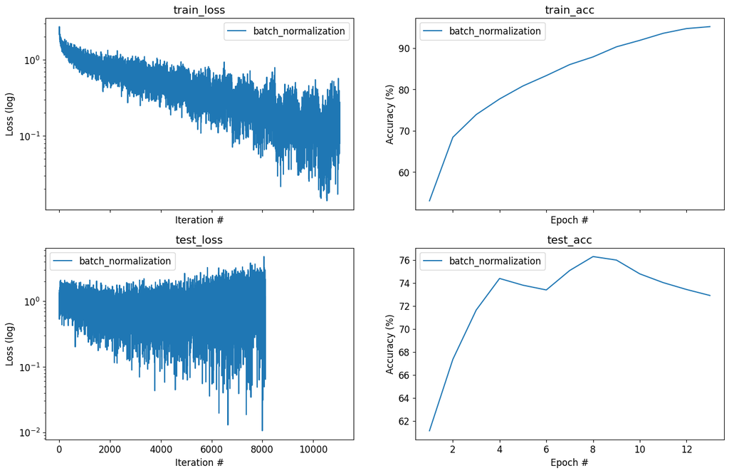

```python
plot_exp_results('exp3_batch_normalization.json') # plot your experiments results
```

**Answer in your Report:** What is the purpose of batch normalization (why do we use it)? Did the Batch normalization improve the network preformance? Summeraize this section results in your report.

### Answer:

Batch normalization does two things, first it normalizes the data between the layers it's in, Meaning the data will be mapped to be between the values 0 and 1. So it will take less time for the next layer to process the data and also avoid having high values which can result in gradient explosion(when a large error gradients accumulate which result in a large update of the weights). The second thing it does is adds a bias and an variable to the data process between the layers it's in, and those are trainable, so it lowers the interal covariate shift problem as well by balancing more between the early layers and the layers closer to the end of the network, so the early layers can be more impactful and the later ones less (if there's a need).

Batch normalization improved the network performance greatly, mainly but improving the test and val accuracy and lowered the test and validation loss, minimizing by a little the overfitting problem which the network had (still has but less now).

### 4. Regularization

Try to add regularization to your optimization. In particular add L2 regularization (read about weight_decay in adam) and dropout layer to your network (try them separately).

```python
# set ycn=True when you call experiments.run_experiment(...)
# Use meaningful names!
# ====== YOUR CODE: ======
experiments.run_experiment(f'exp4_with_L2_Reg0.01',
                                seed=seed,
                                bs_train=50,
                                batches=10000,
                                epochs=20,
                                early_stopping=5,
                                reg=0.01,
                                lr=0.0005,
                                filters_per_layer=[64],
                                layers_per_block=4,
                                pool_every=4,
                                hidden_dims=[100,100],
                                ycn=True,
                                optimizer="Adam")
# ========================
```

```
Files already downloaded and verified
Files already downloaded and verified
YourCodeNet(
  (feature_extractor): Sequential(
    (0): Conv2d(3, 64, kernel_size=(3, 3), stride=(1, 1), padding=(1, 1))
    (1): BatchNorm2d(64, eps=1e-05, momentum=0.1, affine=True, track_running_stats=True)
    (2): ReLU(inplace=True)
    (3): Conv2d(64, 64, kernel_size=(3, 3), stride=(1, 1), padding=(1, 1))
    (4): BatchNorm2d(64, eps=1e-05, momentum=0.1, affine=True, track_running_stats=True)
    (5): ReLU(inplace=True)
    (6): Conv2d(64, 64, kernel_size=(3, 3), stride=(1, 1), padding=(1, 1))
    (7): BatchNorm2d(64, eps=1e-05, momentum=0.1, affine=True, track_running_stats=True)
    (8): ReLU(inplace=True)
    (9): Conv2d(64, 64, kernel_size=(3, 3), stride=(1, 1), padding=(1, 1))
    (10): BatchNorm2d(64, eps=1e-05, momentum=0.1, affine=True, track_running_stats=True)
    (11): ReLU(inplace=True)
    (12): MaxPool2d(kernel_size=2, stride=2, padding=0, dilation=1, ceil_mode=False)
  )
  (classifier): Sequential(
    (0): Linear(in_features=16384, out_features=100, bias=True)
    (1): ReLU(inplace=True)
    (2): Linear(in_features=100, out_features=100, bias=True)
    (3): ReLU(inplace=True)
    (4): Linear(in_features=100, out_features=10, bias=True)
  )
)
--- EPOCH 1/20 ---
train_batch (Avg. Loss 1.307, Accuracy 52.8): 100%|██████████| 850/850 [00:12<00:00, 65.96it/s]
test_batch (Avg. Loss 1.125, Accuracy 59.3): 100%|██████████| 625/625 [00:01<00:00, 328.63it/s]
--- EPOCH 2/20 ---
train_batch (Avg. Loss 0.975, Accuracy 65.7): 100%|██████████| 850/850 [00:13<00:00, 63.63it/s]
test_batch (Avg. Loss 1.057, Accuracy 62.7): 100%|██████████| 625/625 [00:02<00:00, 301.35it/s]
--- EPOCH 3/20 ---
train_batch (Avg. Loss 0.883, Accuracy 68.9): 100%|██████████| 850/850 [00:12<00:00, 65.99it/s]
test_batch (Avg. Loss 0.935, Accuracy 66.6): 100%|██████████| 625/625 [00:02<00:00, 310.81it/s]
--- EPOCH 4/20 ---
train_batch (Avg. Loss 0.827, Accuracy 71.0): 100%|██████████| 850/850 [00:12<00:00, 66.11it/s]
test_batch (Avg. Loss 1.687, Accuracy 48.5): 100%|██████████| 625/625 [00:02<00:00, 303.90it/s]
--- EPOCH 5/20 ---
train_batch (Avg. Loss 0.786, Accuracy 72.7): 100%|██████████| 850/850 [00:12<00:00, 66.27it/s]
```

[output cut: 28 more lines]

```
--- EPOCH 15/20 ---
train_batch (Avg. Loss 0.555, Accuracy 80.8): 100%|██████████| 850/850 [00:12<00:00, 66.29it/s]
test_batch (Avg. Loss 0.707, Accuracy 75.5): 100%|██████████| 625/625 [00:02<00:00, 293.16it/s]
--- EPOCH 16/20 ---
train_batch (Avg. Loss 0.538, Accuracy 81.4): 100%|██████████| 850/850 [00:12<00:00, 65.45it/s]
test_batch (Avg. Loss 0.758, Accuracy 73.4): 100%|██████████| 625/625 [00:02<00:00, 268.78it/s]
--- EPOCH 17/20 ---
train_batch (Avg. Loss 0.526, Accuracy 82.0): 100%|██████████| 850/850 [00:13<00:00, 64.86it/s]
test_batch (Avg. Loss 0.789, Accuracy 71.3): 100%|██████████| 625/625 [00:01<00:00, 336.85it/s]
test_batch (Avg. Loss 0.794, Accuracy 71.6): 100%|██████████| 834/834 [00:05<00:00, 156.72it/s]
==================== Test Results ====================
Test Accuracy: 71.6
Test Accuracy: 0.7936422835490543
======================================================
*** Output file ./results/exp4_with_L2_Reg0.01.json written
```

```python
experiments.run_experiment(f'exp4_with_dropout',
                                seed=seed,
                                bs_train=50,
                                batches=10000,
                                epochs=20,
                                early_stopping=5,
                                reg=0,
                                lr=0.0005,
                                filters_per_layer=[64],
                                layers_per_block=4,
                                pool_every=4,
                                hidden_dims=[100,100],
                                ycn=True,
                                optimizer="Adam")
```

```
Files already downloaded and verified
Files already downloaded and verified
YourCodeNet(
  (feature_extractor): Sequential(
    (0): Conv2d(3, 64, kernel_size=(3, 3), stride=(1, 1), padding=(1, 1))
    (1): BatchNorm2d(64, eps=1e-05, momentum=0.1, affine=True, track_running_stats=True)
    (2): ReLU(inplace=True)
    (3): Dropout(p=0.3, inplace=False)
    (4): Conv2d(64, 64, kernel_size=(3, 3), stride=(1, 1), padding=(1, 1))
    (5): BatchNorm2d(64, eps=1e-05, momentum=0.1, affine=True, track_running_stats=True)
    (6): ReLU(inplace=True)
    (7): Dropout(p=0.3, inplace=False)
    (8): Conv2d(64, 64, kernel_size=(3, 3), stride=(1, 1), padding=(1, 1))
    (9): BatchNorm2d(64, eps=1e-05, momentum=0.1, affine=True, track_running_stats=True)
    (10): ReLU(inplace=True)
    (11): Dropout(p=0.3, inplace=False)
    (12): Conv2d(64, 64, kernel_size=(3, 3), stride=(1, 1), padding=(1, 1))
    (13): BatchNorm2d(64, eps=1e-05, momentum=0.1, affine=True, track_running_stats=True)
    (14): ReLU(inplace=True)
    (15): Dropout(p=0.3, inplace=False)
    (16): MaxPool2d(kernel_size=2, stride=2, padding=0, dilation=1, ceil_mode=False)
  )
  (classifier): Sequential(
    (0): Linear(in_features=16384, out_features=100, bias=True)
    (1): ReLU(inplace=True)
    (2): Linear(in_features=100, out_features=100, bias=True)
    (3): ReLU(inplace=True)
    (4): Linear(in_features=100, out_features=10, bias=True)
  )
)
--- EPOCH 1/20 ---
train_batch (Avg. Loss 1.417, Accuracy 48.5): 100%|██████████| 850/850 [00:13<00:00, 60.82it/s]
test_batch (Avg. Loss 1.257, Accuracy 55.7): 100%|██████████| 625/625 [00:02<00:00, 273.34it/s]
--- EPOCH 2/20 ---
train_batch (Avg. Loss 1.069, Accuracy 61.7): 100%|██████████| 850/850 [00:15<00:00, 58.85it/s]
test_batch (Avg. Loss 1.044, Accuracy 63.4): 100%|██████████| 625/625 [00:02<00:00, 286.32it/s]
--- EPOCH 3/20 ---
train_batch (Avg. Loss 0.896, Accuracy 68.3): 100%|██████████| 850/850 [00:13<00:00, 61.18it/s]
test_batch (Avg. Loss 0.952, Accuracy 66.6): 100%|██████████| 625/625 [00:02<00:00, 293.02it/s]
--- EPOCH 4/20 ---
```

[output cut: 41 more lines]

```
--- EPOCH 18/20 ---
train_batch (Avg. Loss 0.352, Accuracy 87.4): 100%|██████████| 850/850 [00:14<00:00, 59.94it/s]
test_batch (Avg. Loss 0.680, Accuracy 76.6): 100%|██████████| 625/625 [00:02<00:00, 298.37it/s]
--- EPOCH 19/20 ---
train_batch (Avg. Loss 0.339, Accuracy 87.8): 100%|██████████| 850/850 [00:14<00:00, 60.55it/s]
test_batch (Avg. Loss 0.718, Accuracy 76.0): 100%|██████████| 625/625 [00:02<00:00, 310.15it/s]
--- EPOCH 20/20 ---
train_batch (Avg. Loss 0.327, Accuracy 88.3): 100%|██████████| 850/850 [00:14<00:00, 59.71it/s]
test_batch (Avg. Loss 0.724, Accuracy 76.1): 100%|██████████| 625/625 [00:02<00:00, 304.18it/s]
test_batch (Avg. Loss 0.753, Accuracy 75.2): 100%|██████████| 834/834 [00:04<00:00, 169.35it/s]
==================== Test Results ====================
Test Accuracy: 75.18
Test Accuracy: 0.7525841970336166
======================================================
*** Output file ./results/exp4_with_dropout.json written
```

```python
experiments.run_experiment(f'exp4_with_dropout_p0.5',
                                seed=seed,
                                bs_train=50,
                                batches=10000,
                                epochs=30,
                                early_stopping=5,
                                reg=0,
                                lr=0.0005,
                                filters_per_layer=[64],
                                layers_per_block=4,
                                pool_every=4,
                                hidden_dims=[100,100],
                                ycn=True,
                                optimizer="Adam")
```

```
Files already downloaded and verified
Files already downloaded and verified
YourCodeNet(
  (feature_extractor): Sequential(
    (0): Conv2d(3, 64, kernel_size=(3, 3), stride=(1, 1), padding=(1, 1))
    (1): BatchNorm2d(64, eps=1e-05, momentum=0.1, affine=True, track_running_stats=True)
    (2): ReLU(inplace=True)
    (3): Dropout(p=0.5, inplace=False)
    (4): Conv2d(64, 64, kernel_size=(3, 3), stride=(1, 1), padding=(1, 1))
    (5): BatchNorm2d(64, eps=1e-05, momentum=0.1, affine=True, track_running_stats=True)
    (6): ReLU(inplace=True)
    (7): Dropout(p=0.5, inplace=False)
    (8): Conv2d(64, 64, kernel_size=(3, 3), stride=(1, 1), padding=(1, 1))
    (9): BatchNorm2d(64, eps=1e-05, momentum=0.1, affine=True, track_running_stats=True)
    (10): ReLU(inplace=True)
    (11): Dropout(p=0.5, inplace=False)
    (12): Conv2d(64, 64, kernel_size=(3, 3), stride=(1, 1), padding=(1, 1))
    (13): BatchNorm2d(64, eps=1e-05, momentum=0.1, affine=True, track_running_stats=True)
    (14): ReLU(inplace=True)
    (15): Dropout(p=0.5, inplace=False)
    (16): MaxPool2d(kernel_size=2, stride=2, padding=0, dilation=1, ceil_mode=False)
  )
  (classifier): Sequential(
    (0): Linear(in_features=16384, out_features=100, bias=True)
    (1): ReLU(inplace=True)
    (2): Linear(in_features=100, out_features=100, bias=True)
    (3): ReLU(inplace=True)
    (4): Linear(in_features=100, out_features=10, bias=True)
  )
)
--- EPOCH 1/30 ---
train_batch (Avg. Loss 1.451, Accuracy 47.2): 100%|██████████| 850/850 [00:13<00:00, 61.11it/s]
test_batch (Avg. Loss 1.408, Accuracy 50.5): 100%|██████████| 625/625 [00:01<00:00, 318.46it/s]
--- EPOCH 2/30 ---
train_batch (Avg. Loss 1.122, Accuracy 59.7): 100%|██████████| 850/850 [00:13<00:00, 61.02it/s]
test_batch (Avg. Loss 1.164, Accuracy 61.9): 100%|██████████| 625/625 [00:01<00:00, 317.01it/s]
--- EPOCH 3/30 ---
train_batch (Avg. Loss 0.968, Accuracy 65.6): 100%|██████████| 850/850 [00:13<00:00, 61.45it/s]
test_batch (Avg. Loss 0.991, Accuracy 68.3): 100%|██████████| 625/625 [00:02<00:00, 296.20it/s]
--- EPOCH 4/30 ---
```

[output cut: 68 more lines]

[output not shown]

[output not shown]

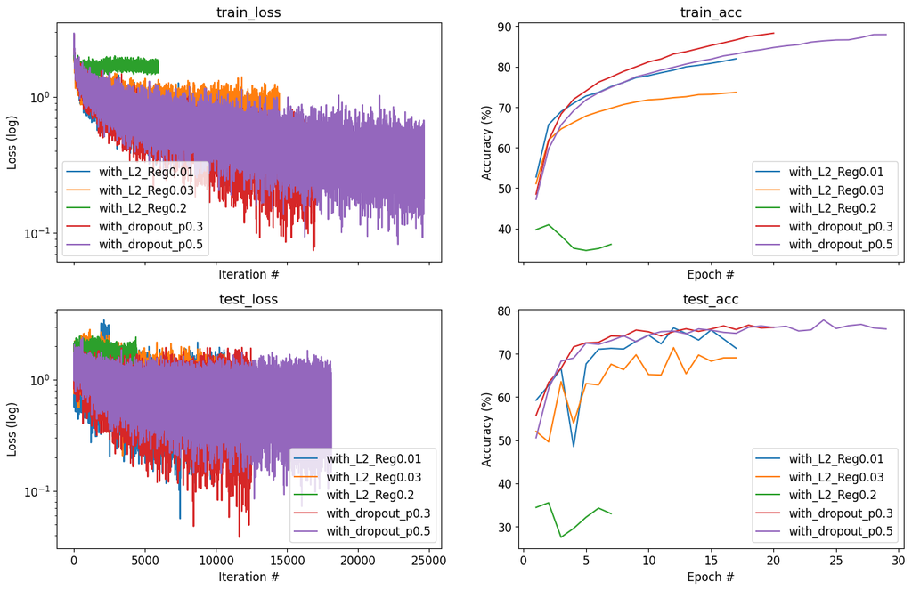

```python
plot_exp_results('exp4*.json') # plot your experiments results
```

**Answer in your Report:** Why should we use regularization? How does the regularization affect the train accuracy and loss? How does it affect the val and test accuracy and loss? What was the best regulrization method? Summarize this section results in your report.

### Answer:

We should use regularization to fix the overfitting problem, overfitting happened when the model learns the training dataset "too much" in a way that it learns also the noise and the finds that correlate only to the learning datasets, and not the real world (or validation and test datasets) so since regularization helps minimize and avoid the overfitting problem it lowers the train accuracy to match more closely to the test accuracy, meaning the loss of the test and validation won't increase too much while the loss of the training is decreasing therefore minimizing the overfitting problem.

regularization makes the variance of the network be effected by the weights of the network, if a certain weight is too high it's a indication that the model is overfitting, so it penalizes the model for higher weights. Dropout makes a neuron have a probability of being inactive (p) that way the network won't rely too much on certain neurons which will lead to other neurons to learn less (which makes a weight more high by being more dependable).

In my model I found dropout with probability of 0.5 to have the best results and the best validation accuracy.

## Summary Up To Here

**Answer in your Report:** What is your best architecture? what its best accuracy and loss on the test set? Compare your result to assignment 2. How did you mange to improve the model? Summarize this section results in your report.

### Answer:

The end result of the best architecture i found was 4 layers per block with 64 filters per layer with hidden dim of [100,100] with batch normalization and dropout with 50%. the final accuracy and loss the network achieved are:

Accuracy: 76.07

Loss: 0.6966445505154505

compared to assignment 2, I've experimented with dropout and not only L2 regulation and also experimented with different hidden dimensions, also I added to this network batch normalization unlike the last assignment. Compared to last assignmnet the results of this network are much better, with %76.07 accuracy compared to %68.66 and 0.696 loss compared to 0.945. So overall a big improvement from the last assignment network.

## Use predefined network

You may want to read about ResNet in this blog:

https://towardsdatascience.com/an-overview-of-resnet-and-its-variants-5281e2f56035

### 5. Pretrained ResNet50

Now use ResNet50 with pretraining (use pretrained=True when you load the model) and run this model on cifar 10. you will need to change the last linear layer. Tip: `model.fc = nn.Linear(2048, 10)`. you may want to use lower learning rate.

```python
import torchvision.models as models
# Use meaningful names!
# ====== YOUR CODE: ======
resnet50 = models.resnet50(pretrained=True)
resnet50.fc = nn.Linear(2048, 10)
resnet50 = resnet50.to(device)
experiments.run_experiment('exp5_resnet50',
                                seed=seed,
                                bs_train=50,
                                batches=10000,
                                epochs=10,
                                early_stopping=5,
                                reg=2e-4,
                                lr=0.0001,
                                optimizer="Adam",
                                model=resnet50)
```

[output not shown]

```
common config:  {'run_name': 'resnet50', 'out_dir': './results', 'seed': 42, 'bs_train': 50, 'bs_test': 12, 'batches': 10000, 'epochs': 10, 'early_stopping': 5, 'checkpoints': None, 'lr': 0.0001, 'reg': 0.0002, 'pool_every': 2, 'hidden_dims': [1024], 'ycn': False, 'kw': {'optimizer': 'Adam', 'model'…
```

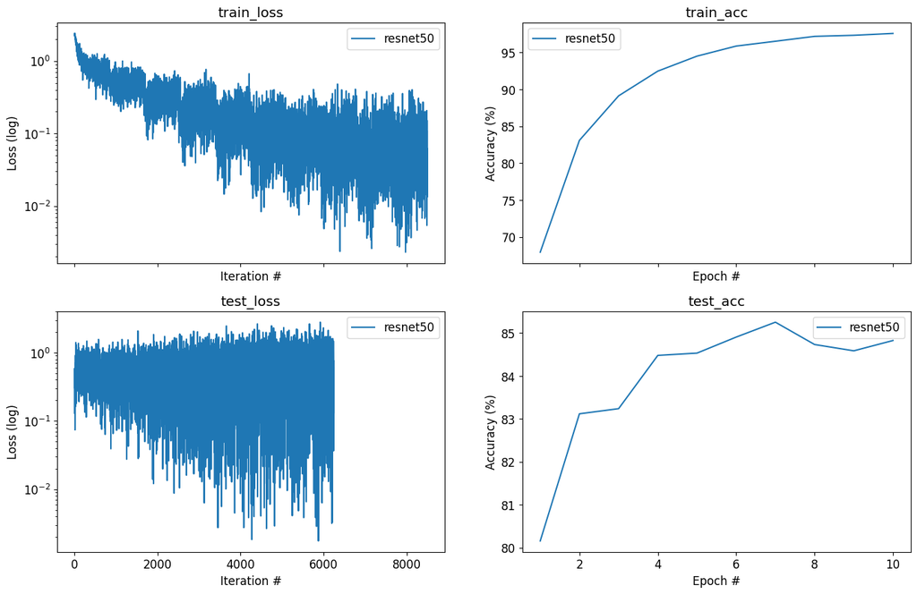

```python
plot_exp_results('exp5_*.json') # plot your experiments results
```

**Answer in your Report:** What was the pretrained ResNet50 accuracy and loss? Is it overfit/underfit/well-fit the data? Has it got better accuracy than your model? Summarize this section results in your report.

### Answer:

After training with the pretrained ResNet50 the accuracy and lost were:

Accuracy: 83.75

Loss: 0.6220886492896524

Which is better then my model which ended up with:

Accuracy: 76.07

Loss: 0.6966445505154505

since the loss is lower and the accuracy is higher it had better results then my model. The ResNet50 model did overfit a bit, more then my model since it's train loss which is 0.071 is way lower then the test loss. Probably could've been avoided if I ran only 5 epochs on it.

### 5. Summeraize these blogs

Read these blogs (and any other material you want):

1. https://towardsdatascience.com/r-cnn-fast-r-cnn-faster-r-cnn-yolo-object-detection-algorithms-36d53571365e
2. https://jonathan-hui.medium.com/what-do-we-learn-from-region-based-object-detectors-faster-r-cnn-r-fcn-fpn-7e354377a7c9

Write a summarization RCNN, fast RCNN and faster RCNN (between one to two pages, in hebrew). Be sure that you answer the following question in your summarization (and add more info about this area, this is just a sanity check for you):

1. which task we are trying to address using those models? what is the loss function that we use for this task?
2. what is the region-based object detectors and what is the main difference between this approach (which includes those models) and the single shot object detectors?
3. what are the main improvements between RCNN->Fast RCNN-> Faster RCNN?
4. what is the ROI pooling layer?

## Project Summary

**Answer in your Report:** Write a short summerization of your attempts. What worked for you? which architecture and hyperparameters led to the best preformance? which future experiments you may want to do and why? please also suggest at least two ways you believe you may improve the preformace of the model.

### Answer:

I ended up using a model with 64 filters per layer, 4 layers per block and hidden dims of size [100,100] since it had the best accuracy at the start, then learning rate of 0.0005 with Adam optimizer although Adam with LR of 0.001 and SGD with 0.1 had almost the same results. Also, the batch normalization increased the performance of my model by a lot but regularization increased it by a lot less. I ended up using regularization of dropout with probability of 0.5. the end result was %76.07 accuracy and 0.6966 loss. I actually tried a lot more models even some that didn't perform well at the start for example I've found that a model with 256 filters per layer and 4 layers per block and hidden dims of size [256,256] won't performed well without regularization and batch normalization but after implementing those improvements the model performed just as good as the one I ended up using. So I discovered that some combinations work well although alone they don't do so well, want to experiment with different combinations and I believe that I will found a better combination and thus a better model. Also I didn't experiment with the max pooling, which also effect the model performance and could also improve the model. Last thing is ResNet50 made me realize that not all models are build evenly throughout. And maybe choosing one variable as the filters per layer isn't optimal, maybe building a combination of small networks (like ResNet50 which had much better performance) could work better.